# Jupyter notebooks in education

**Zsolt Elter, Andreas Solders**

*TK Talk, 2020 March*

# Content

- Context - Energy physics II with nuclear energy
- Brief overview of Jupyter notebooks
- Lot of demonstration
- Feed-back and Feed-forward
- Hopefully a lot of Q&A (we need ideas for notebooks:))

# Course where implemented

- Energy Physics II with Nuclear Energy, 10.0 c (first part)
- Introductory reactor physics
  - Neutron cross sections
  - Neutron slowing down
  - Neutron diffusion
  - Point kinetics
- Large variety of data is involved (cross sections, nubar, spectra)
- Reactor physics is driven by computations
- Ideal case for Problem-based learning

# Course where implemented

- Energy Physics II with Nuclear Energy, 10.0 c (first part)
- Instructions
  - Traditional lectures
  - Tutorials
  - Seminars, computer exercise, study visit, ...
- Examination
  - Home assignments
  - Oral exam

# Usage in the course

- Tutorial solutions (show plots and equations)
- Interactive plots in lectures
- Home assignments
  - Students receive introduction
  - Data (eg. cross section or measurement)
  - Instructions
  - Then they write the exercise in the notebook

# What is a Jupyter notebook?

Browser-based document mixing

1. Narrative text written in Markdown
   - Markdown is a very **simple** and *easy to learn* markup language, aka difficult.
2. Equations written in $\LaTeX$
3. Live, executable code (eg. `python`)
4. Visualizations (eg. matplotlib)
5. Hyperlinks:
   - [Markdown Cheatsheet](https://github.com/adam-p/markdown-here/wiki/Markdown-Cheatsheet)
6. Figures

[figure not shown]

Might be familiar to Wolfram Mathematica users!

# Slide shows

- Save the Notebook as a slide show (File -> Download as -> Reveal.js slides (.slides.html)
  - Run it in a browser of you choice
  - Passive!
- Alternatively, use RISE to activly display your NB in your browser (like this pressentation)
  - Make changes to your slide while pressenting
  - Draw directly in the slide
  - Draw on a chalk board
  - Execute code directly in the slide!

# Python code - first example

One describes some problem with equations, then some code.

$$f(t)=C\cdot t^3$$

```python
import matplotlib.pyplot as plt
import numpy as np
```

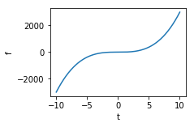

```python
C=3
t=np.linspace(-10,10,1000)
plt.figure(figsize=(3, 2))
plt.plot(t,C*t**3)
plt.xlabel('t')
plt.ylabel('f')
plt.show()
```

# What else?

It is ideal for

- A report (popular in data science)
- Data analysis code documentation
- Apparently, also a slideshow
- Textbook for education
- [Examples for APIs](https://github.com/ezsolti/feign/tree/master/examples)

But! Not very comfortable

- For scripting and Software development
- Don't throw away your preferred editor yet:)

# How is it viewed?

- Can be exported to latex (thus pdf)
- Can be exported to html
- github renders it nicely
- But! Ideally as a jupyter notebook file opened in browser.

So students need jupyter to be installed?

- Ideally, yes. (comes with Anaconda)
- Jupyterhub? Not tested by us
- https://mybinder.org/

All of our students managed to install jupyter!

# Demonstrations

[you can try it here](https://mybinder.org/v2/gh/ezsolti/EnergyPhysics/master)

# Demonstrations

- Week 1 tutorial
- XS plotting assignment
- Area method assignment
- 1/N method assignment
- Numerical method assignment

# Feedbacks

- Steep learning curve
  - Installing jupyter was not straightforward
  - Programming knowledge is often missing
  - Can we expect a *for* loop?
- Correcting is a bit problematic
  - Students did not include their name
  - Some students did not change filename
  - We will need to explicicitly include instructions for that!
- Even some other assignments were submitted as notebooks: WOW!
- ”Feels more like actual research, it is fun”

# Future

- More assignments
- Several worked examples
- Textbook chapters?
- Combining with Flipped Classroom?
- Implement in other coursework?
  - OpenMC, OpenMOC have [python API](https://docs.openmc.org/en/stable/examples/pincell.html)
  - Could we bring hardcore reactor physics to students through notebooks?